# Titanic ML - Kaggle Tutorial

Javeed Basha

July 29, 2017

## Data Initialization

Let’s begin with our analysis of Titanic Dataset using ML.

```r
titanic_train <- read.csv("train.csv", stringsAsFactors = FALSE)

titanic_test <- read.csv("test.csv", stringsAsFactors = FALSE)

# Analyzing the Structure of the Data Frame
str(titanic_train)
```

```
## 'data.frame':    891 obs. of  12 variables:
##  $ PassengerId: int  1 2 3 4 5 6 7 8 9 10 ...
##  $ Survived   : int  0 1 1 1 0 0 0 0 1 1 ...
##  $ Pclass     : int  3 1 3 1 3 3 1 3 3 2 ...
##  $ Name       : chr  "Braund, Mr. Owen Harris" "Cumings, Mrs. John Bradley (Florence Briggs Thayer)" "Heikkinen, Miss. Laina" "Futrelle, Mrs. Jacques Heath (Lily May Peel)" ...
##  $ Sex        : chr  "male" "female" "female" "female" ...
##  $ Age        : num  22 38 26 35 35 NA 54 2 27 14 ...
##  $ SibSp      : int  1 1 0 1 0 0 0 3 0 1 ...
##  $ Parch      : int  0 0 0 0 0 0 0 1 2 0 ...
##  $ Ticket     : chr  "A/5 21171" "PC 17599" "STON/O2. 3101282" "113803" ...
##  $ Fare       : num  7.25 71.28 7.92 53.1 8.05 ...
##  $ Cabin      : chr  "" "C85" "" "C123" ...
##  $ Embarked   : chr  "S" "C" "S" "S" ...
```

```r
str(titanic_test)
```

```
## 'data.frame':    418 obs. of  11 variables:
##  $ PassengerId: int  892 893 894 895 896 897 898 899 900 901 ...
##  $ Pclass     : int  3 3 2 3 3 3 3 2 3 3 ...
##  $ Name       : chr  "Kelly, Mr. James" "Wilkes, Mrs. James (Ellen Needs)" "Myles, Mr. Thomas Francis" "Wirz, Mr. Albert" ...
##  $ Sex        : chr  "male" "female" "male" "male" ...
##  $ Age        : num  34.5 47 62 27 22 14 30 26 18 21 ...
##  $ SibSp      : int  0 1 0 0 1 0 0 1 0 2 ...
##  $ Parch      : int  0 0 0 0 1 0 0 1 0 0 ...
##  $ Ticket     : chr  "330911" "363272" "240276" "315154" ...
##  $ Fare       : num  7.83 7 9.69 8.66 12.29 ...
##  $ Cabin      : chr  "" "" "" "" ...
##  $ Embarked   : chr  "Q" "S" "Q" "S" ...
```

From, the Datasets, we can now understand that a total of 891 observations of 12 variables are present in the Train Dataset and a total of 418 Observations of 11 variables are present in Test Dataset.

Each and every Data Scientist has his own way of interpreting the data and please do note that one can improve the accuracy and the efficiency of the data by utilising many variables in a way or other. Here, In order to keep it simple, I have utilised minimal variables.

## Numbers Game

```r
# Survival rates in absolute numbers
print("Survival Rates(ABS):")
```

```
## [1] "Survival Rates(ABS):"
```

```r
table(titanic_train$Survived)
```

```
##
##   0   1
## 549 342
```

```r
# Survival rates in proportions
print("Survival Rates(%):")
```

```
## [1] "Survival Rates(%):"
```

```r
prop.table(table(titanic_train$Survived))
```

```
##
##         0         1
## 0.6161616 0.3838384
```

```r
# Two-way comparison: Sex and Survived
print("Survival Rates Male & Female(ABS):")
```

```
## [1] "Survival Rates Male & Female(ABS):"
```

```r
table(titanic_train$Sex, titanic_train$Survived)
```

```
##
##            0   1
##   female  81 233
##   male   468 109
```

```r
# Two-way comparison: row-wise proportions
print("Survival Rates Male & Female(%):")
```

```
## [1] "Survival Rates Male & Female(%):"
```

```r
prop.table(table(titanic_train$Sex, titanic_train$Survived), 1)
```

```
##
##                  0         1
##   female 0.2579618 0.7420382
##   male   0.8110919 0.1889081
```

## Plots for the Survival Rate

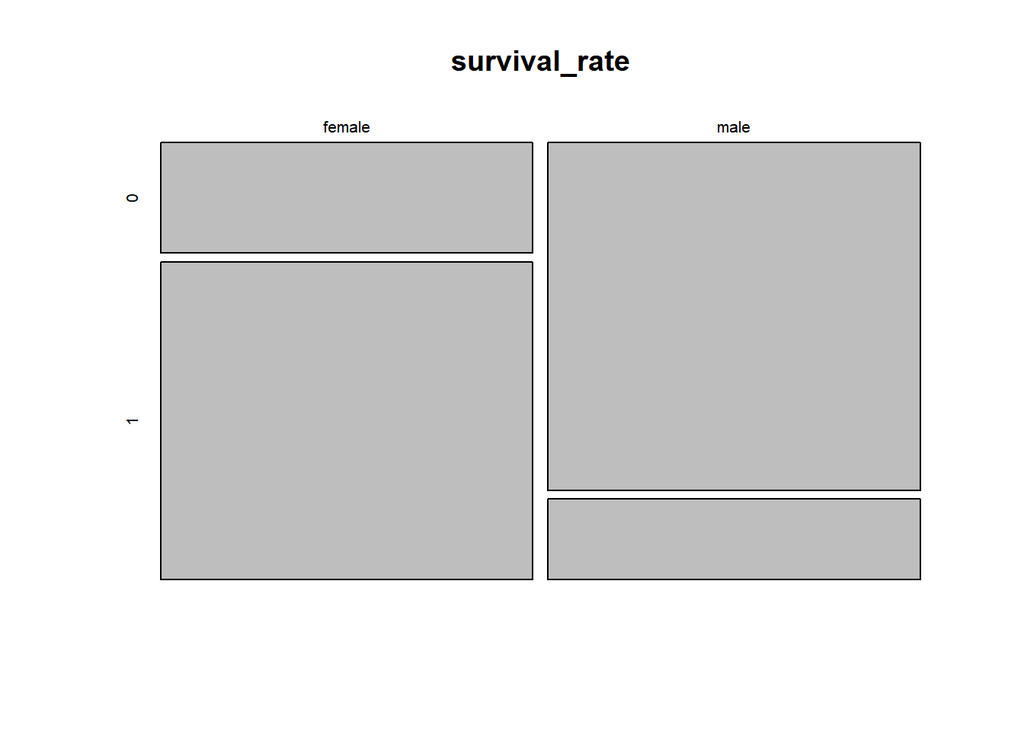

As, can be noted from the above plots, the survival rates of female are higher than male.

## Age!!!

```r
# Creating a new column child
# Initialising a new column
titanic_train$Child <- NA
titanic_train$Child[titanic_train$Age < 18] <- 1
titanic_train$Child[titanic_train$Age >= 18] <- 0

# Two-way comparison
prop.table(table(titanic_train$Child, titanic_train$Survived), 1)
```

```
##
##             0         1
##   0 0.6189684 0.3810316
##   1 0.4601770 0.5398230
```

## First Analysis

We use the test set for validating our predictions. We can notice that, contrary to the training set, the test set has no Survived column. We can add such a column using our predicted values. Next, when uploading our results, Kaggle will use this column (= our predictions) to score your performance.

```r
# Copy of test
test <- titanic_test

# Initialize a Survived column to 0
test$Survived <- 0

# Set Survived to 1 if Sex equals "female"
test$Survived[titanic_test$Sex == "female"] <- 1

# Initial Solution
my_solution <- data.frame(PassengerID = test$PassengerId, Survived = test$Survived)

# Write the solution to file
write.csv(my_solution, file = 'my_solution.csv', row.names = F)
```

Please do note, that this solution takes into consideration that almost all females survived in the test dataset and also has lesser accuracy.

We now implement ML techniques to improve our accuracy and score.

## ML Techniques

```r
library(rpart)
library(rattle)
```

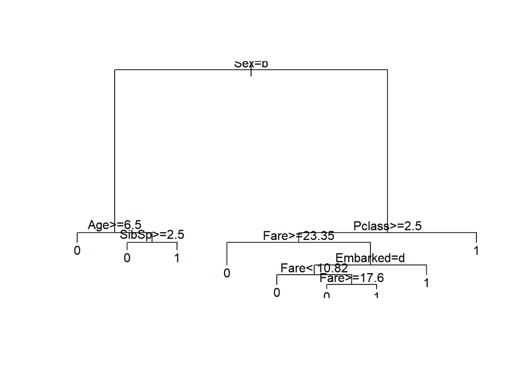

```r
library(rpart.plot)
library(RColorBrewer)

# Build the decision tree
decision_tree <- rpart(Survived ~ Pclass + Sex + Age + SibSp + Parch + Fare + Embarked, data = titanic_train, method = "class")

# Visualize the decision tree using plot() and text()
plot(decision_tree)
text(decision_tree)
```

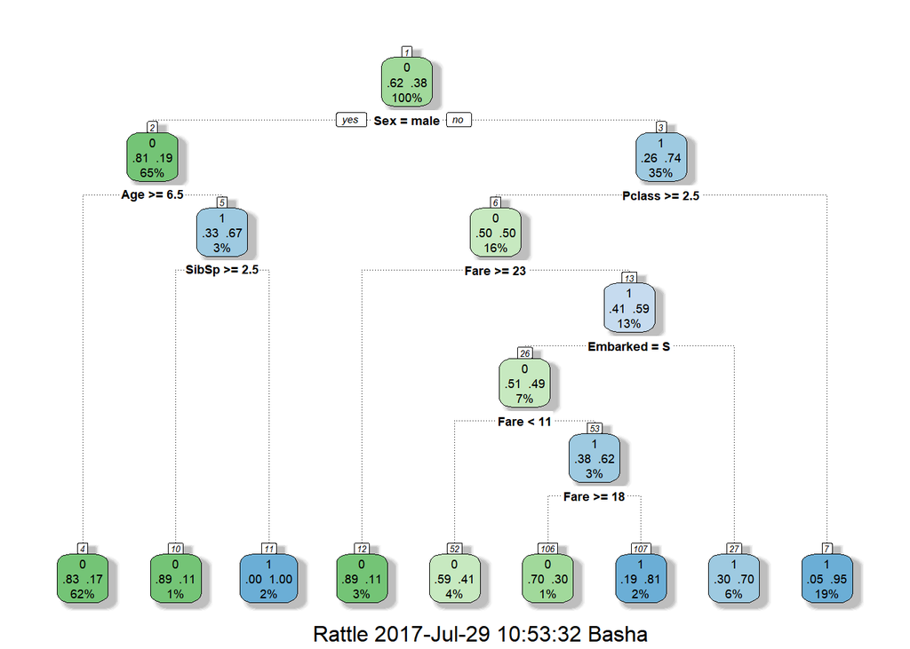

```r
# Fancy tree
fancyRpartPlot(decision_tree)
```

Based on the Fancy Plot, we can understand that Sex, Age, Pclass, Fare and SibSp plays an important role.

## Decision Tree Predictions

```r
# Making predictions on the test set
my_pred <- predict(decision_tree, newdata = titanic_test, type = "class")

# Finishing the data.frame() call
my_solution1 <- data.frame(PassengerId = titanic_test$PassengerId, Survived = my_pred)

# Using nrow() on my_solution to check number of rows
nrow(my_solution1)
```

```
## [1] 418
```

```r
# Finish the write.csv() call
write.csv(my_solution1, file = "my_solution1.csv", row.names = FALSE)
```

Your submission scored 0.78469, which is an improvement of your previous score of 0.76555. Great job!

## Improving Decision Tree

Adding **cp** determines when the splitting up of the decision tree stops.

Adding **minsplit** determines the minimum amount of observations in a leaf of the tree.

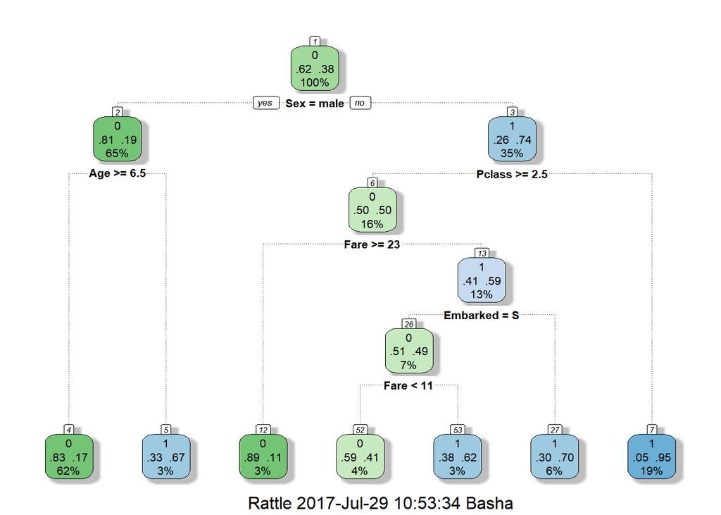

```r
dt_improved <- rpart(Survived ~ Pclass + Sex + Age + SibSp + Parch + Fare + Embarked,
                     data = titanic_train, method = "class",
                     control = rpart.control(minsplit = 50, cp = 0))

# Visualization
fancyRpartPlot(dt_improved)
```

Looks like our Decision Tree has improved to much better outlook. Let’s perform feature engineering in order to improve our score more.

## Feature Engineering

Adding a new feature Family Size and understanding it’s importance by plotting it.

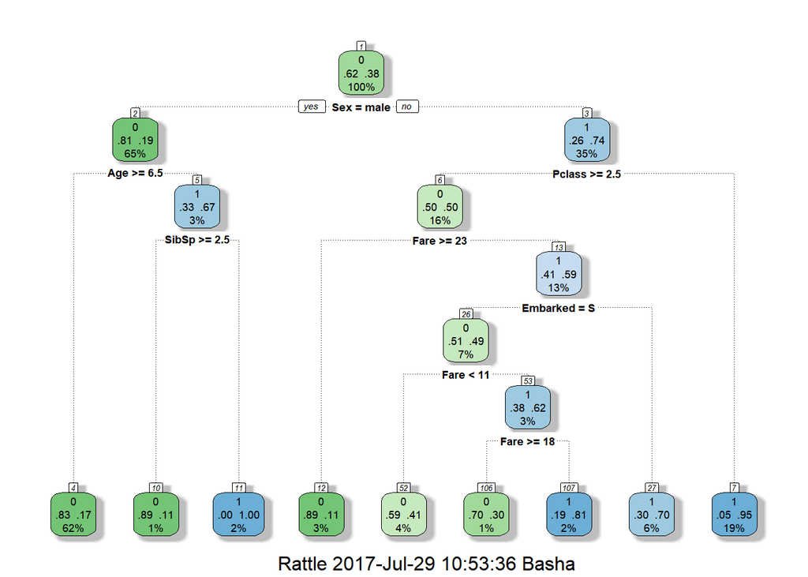

```r
# Creating a Train Sample
train_sample <- titanic_train
train_sample$family_size <- train_sample$SibSp + train_sample$Parch + 1

# Implementataion.
dt_feature <- rpart(Survived ~ Pclass + Sex + Age + SibSp + Parch + Fare + Embarked +
                      family_size, data = train_sample, method = "class")

# Visualization
fancyRpartPlot(dt_feature)
```

As can be noted in the above DT Plot, our feature engineering play no role in deciding the suvivability rate.

[figure not shown]

```r
#Creating Samples
train1 <- titanic_train
test1 <- titanic_test

# Using Passenger Names
pass_names <- train1$Name
pass_names1 <- test1$Name

# Differentiating Titles
titles <- gsub(pattern = "^.*, (.*?)\\..*$", "\\1", pass_names)
titles1 <- gsub(pattern = "^.*, (.*?)\\..*$", "\\1", pass_names1)

# Adding Title to the Dataset
train1$Title <- titles
test1$Title <- titles1

# New DT
dt_feature1 <- rpart(Survived ~ Pclass + Sex + Age + SibSp + Parch + Fare + Embarked +
                       Title,data = train1, method = "class")

# Plotting
fancyRpartPlot(dt_feature1)
```

```r
# Conversion of Dona to Mrs
test1$Title[test1$Title == "Dona"] <- "Mrs"
```

As, you can note from the plot above, our newly featured variable is used in decision making. Now, lets make predictions using this feature.

```r
# Calcualtions
library(ROCR)
# Make prediction
my_pred1 <- predict(dt_feature1, newdata = test1, type = "class")

# Submission
my_solution2 <- data.frame(PassengerId = test1$PassengerId, Survived = my_pred1)

write.csv(my_solution2, file = "my_solution2.csv", row.names = FALSE)
```

Your submission scored 0.80383, which is an improvement of your previous score of 0.78469. Great job!

## Combining the DataSet

```r
library(dplyr)
all_data <- bind_rows(train1, test1)

all_data$family_size <- all_data$SibSp + all_data$Parch + 1

# Dropping Child Columns
drops <- c("Child")
all_data <- all_data[ , !(names(all_data) %in% drops)]

# Passenger on row 62 and 830 do not have a value for embarkment.
# Since many passengers embarked at Southampton, we give them the value S.
all_data$Embarked[c(62, 830)] <- "S"

# Factorize embarkment codes.
all_data$Embarked <- factor(all_data$Embarked)

# Passenger on row 1044 has an NA Fare value. Let's replace it with the median fare value.
all_data$Fare[1044] <- median(all_data$Fare, na.rm = TRUE)

# How to fill in missing Age values?
# We make a prediction of a passengers Age using the other variables.
# This time we use method = "anova" since we are predicting a continuous variable.
predicted_age <- rpart(Age ~ Pclass + Sex + SibSp + Parch + Fare + Embarked + Title +
                         family_size, data = all_data[!is.na(all_data$Age),],
                       method = "anova")

all_data$Age[is.na(all_data$Age)] <- predict(predicted_age, all_data[is.na(all_data$Age),])

# Split the data back into a train set and a test set
train2 <- all_data[1:891,]
test2 <- all_data[892:1309,]

# Factor Conversion
cols <- c("Sex", "Ticket", "Cabin", "Title")
train2[cols] <- lapply(train2[cols], factor)
test2[cols] <- lapply(test2[cols], factor)

# Level out the Factors, cause they might give you errors when doind predictions.
# The Training and The Test data should have same factor levels.
levels(test2$Ticket) <- levels(train2$Ticket)
levels(test2$Title) <- levels(train2$Title)
levels(test2$Cabin) <- levels(train2$Cabin)

str(train2)
```

```
## 'data.frame':    891 obs. of  14 variables:
##  $ PassengerId: int  1 2 3 4 5 6 7 8 9 10 ...
##  $ Survived   : int  0 1 1 1 0 0 0 0 1 1 ...
##  $ Pclass     : int  3 1 3 1 3 3 1 3 3 2 ...
##  $ Name       : chr  "Braund, Mr. Owen Harris" "Cumings, Mrs. John Bradley (Florence Briggs Thayer)" "Heikkinen, Miss. Laina" "Futrelle, Mrs. Jacques Heath (Lily May Peel)" ...
##  $ Sex        : Factor w/ 2 levels "female","male": 2 1 1 1 2 2 2 2 1 1 ...
##  $ Age        : num  22 38 26 35 35 ...
##  $ SibSp      : int  1 1 0 1 0 0 0 3 0 1 ...
##  $ Parch      : int  0 0 0 0 0 0 0 1 2 0 ...
##  $ Ticket     : Factor w/ 681 levels "110152","110413",..: 524 597 670 50 473 276 86 396 345 133 ...
##  $ Fare       : num  7.25 71.28 7.92 53.1 8.05 ...
##  $ Cabin      : Factor w/ 148 levels "","A10","A14",..: 1 83 1 57 1 1 131 1 1 1 ...
##  $ Embarked   : Factor w/ 3 levels "C","Q","S": 3 1 3 3 3 2 3 3 3 1 ...
##  $ Title      : Factor w/ 17 levels "Capt","Col","Don",..: 12 13 9 13 12 12 12 8 13 13 ...
##  $ family_size: num  2 2 1 2 1 1 1 5 3 2 ...
```

```r
str(test2)
```

```
## 'data.frame':    418 obs. of  14 variables:
##  $ PassengerId: int  892 893 894 895 896 897 898 899 900 901 ...
##  $ Survived   : int  NA NA NA NA NA NA NA NA NA NA ...
##  $ Pclass     : int  3 3 2 3 3 3 3 2 3 3 ...
##  $ Name       : chr  "Kelly, Mr. James" "Wilkes, Mrs. James (Ellen Needs)" "Myles, Mr. Thomas Francis" "Wirz, Mr. Albert" ...
##  $ Sex        : Factor w/ 2 levels "female","male": 2 1 2 2 1 2 1 2 1 2 ...
##  $ Age        : num  34.5 47 62 27 22 14 30 26 18 21 ...
##  $ SibSp      : int  0 1 0 0 1 0 0 1 0 2 ...
##  $ Parch      : int  0 0 0 0 1 0 0 1 0 0 ...
##  $ Ticket     : Factor w/ 681 levels "110152","110413",..: 153 222 74 148 139 262 159 85 101 270 ...
##  $ Fare       : num  7.83 7 9.69 8.66 12.29 ...
##  $ Cabin      : Factor w/ 148 levels "","A10","A14",..: 1 1 1 1 1 1 1 1 1 1 ...
##  $ Embarked   : Factor w/ 3 levels "C","Q","S": 2 3 2 3 3 3 2 3 1 3 ...
##  $ Title      : Factor w/ 17 levels "Capt","Col","Don",..: 5 6 5 5 6 5 4 5 6 5 ...
##  $ family_size: num  1 2 1 1 3 1 1 3 1 3 ...
```

## Random Forest Algorithm

For RF Algorithm, we make use of the randomforest library package available.

- First we provide the formula. There is no argument class here to inform the function you’re dealing with predicting a categorical variable, so you need to turn Survived into a factor with two levels: as.factor(Survived) ~ Pclass + Sex + Age
- When we put the importance argument to TRUE we can inspect variable importance.
- The ntree argument specifies the number of trees to grow. Limit these when having only limited computational power at your disposal.
- Since Random Forest uses randomization, we set a seed like this set.seed(111) to assure reproducibility of our results. Once the model is constructed, we can use the prediction function predict().

```r
library(randomForest)
```

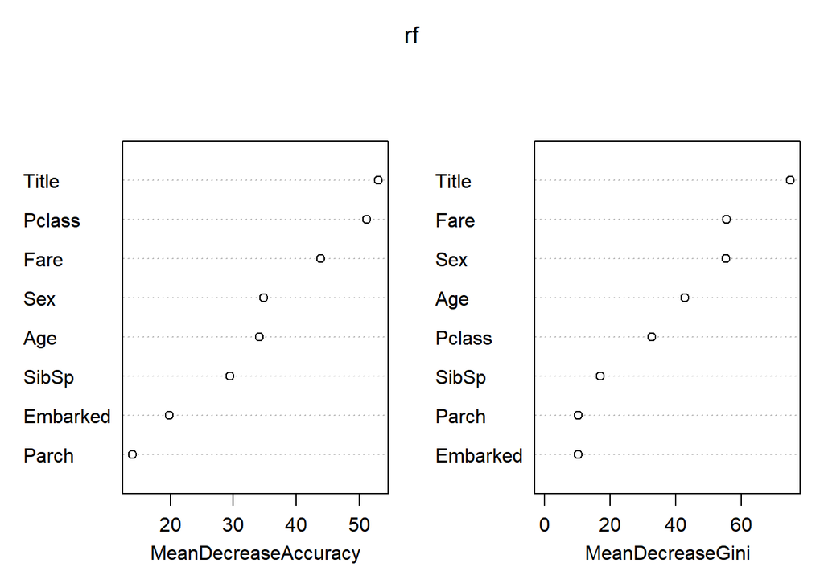

```r
# Set seed for reproducibility
set.seed(111)

# Apply the Random Forest Algorithm
rf <- randomForest(as.factor(Survived) ~ Pclass + Sex + Age + SibSp + Parch + Fare +
                          Embarked + Title, data = train2, importance = TRUE,
                          ntree = 1000)

# Prediction
my_pred2 <- predict(rf, test2)

# Kaggle Solution
my_solution3 <- data.frame(PassengerId = test2$PassengerId, Survived = my_pred2)

# Write your solution away to a csv file with the name my_solution.csv
write.csv(my_solution3, file = "my_solution3.csv", row.names = FALSE)

# Plotting IMP Varaibles
varImpPlot(rf)
```

Your submission scored 0.74641, which is not an improvement of your best score. Keep trying!